# Deliverable 2

# Hierarchical Clustering (from MCA)

```r
res.hcpcMCA <- HCPC(res.mca,nb.clust = 5, order = TRUE)
```

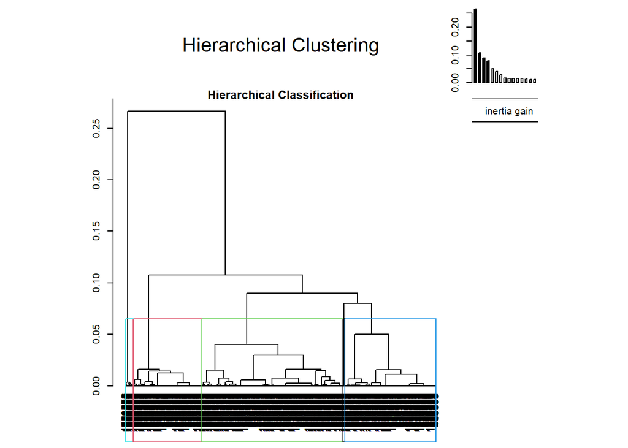

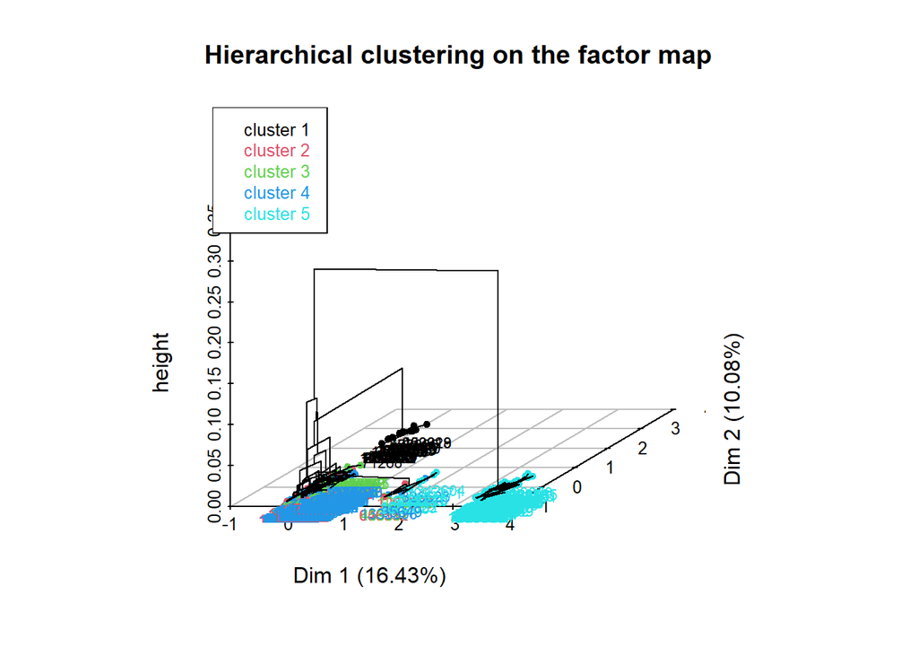

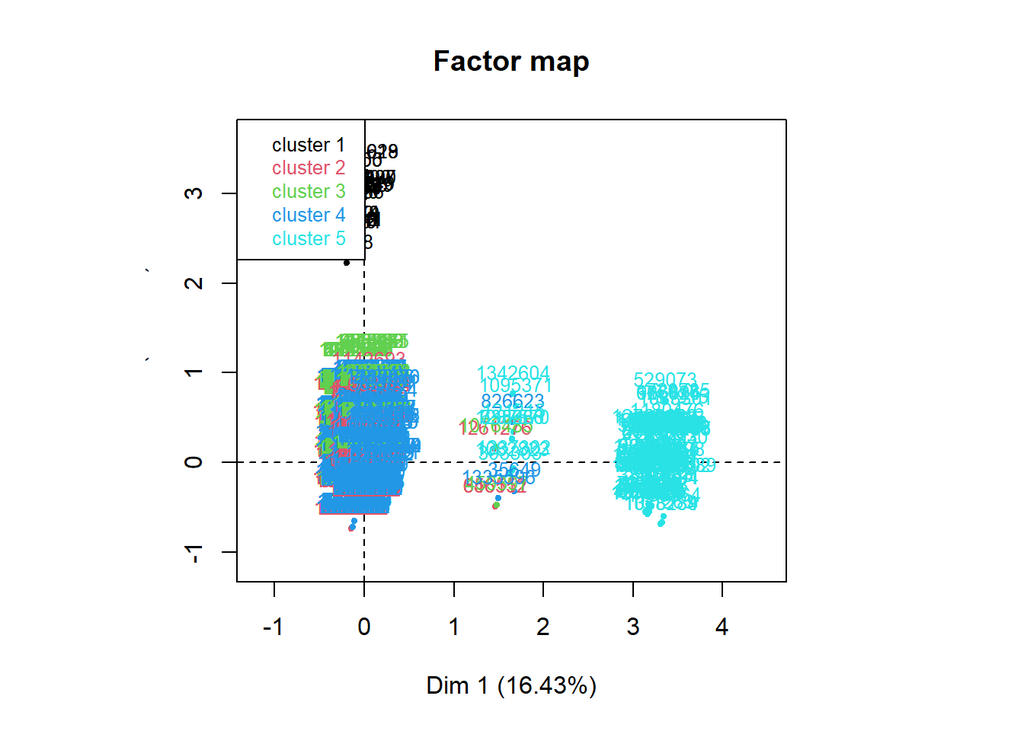

*Note*: If we chose the default number of cluster it would be 5, as we can guess from the inertia reduction plot, that follows the Elbow’s rule (number of black lines plus 1). In our case, after trying with bigger number of clusters, we decided that the default number of cluster was fine for our case and data.

## Description of clusters

Number of observations in each cluster:

```r
table(res.hcpcMCA$data.clust$clust)
```

```
##
##    1    2    3    4    5
##   30 1088 1433 1952  120
```

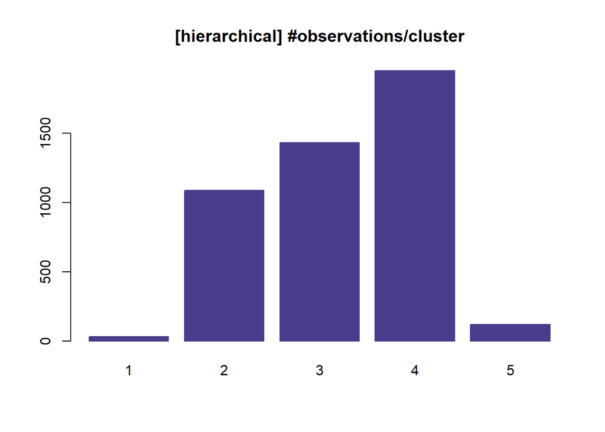

```r
barplot(table(res.hcpcMCA$data.clust$clust), col="darkslateblue", border="darkslateblue", main="[hierarchical] #observations/cluster")
```

## Interpret the results of the classification

### The description of the clusters by the variables

```r
names(res.hcpcMCA$desc.var)
```

```
## [1] "test.chi2"  "category"   "quanti.var" "quanti"     "call"
```

```r
res.hcpcMCA$desc.var$test.chi2   # categorical variables which characterizes the clusters
```

```
##                          p.value df
## RateCodeID          0.000000e+00  4
## Payment_type        0.000000e+00  8
## Trip_type           0.000000e+00  4
## period              0.000000e+00 12
## passenger_groups    2.601045e-94  8
## Trip_distance_range 6.685645e-92  8
## f.cost              1.448630e-51 20
## VendorID            2.325462e-27  4
## TipIsGiven          2.455088e-11  4
```

We start wit the description of the categorical variables that characterize the clusters, so in this output we do not have dimensions because it is the total association. We can see the intensity of the variables, in our case the variables that affect more to the clustering are **RateCodeID**, **Payment_type**, **Trip_type** and **period** because are the one with the smallest p.value. The variables associated to the clusters are the ones that appear on the output.

```r
res.hcpcMCA$desc.var$category    # description of each cluster by the categories
```

```
## $`1`
##                                Cla/Mod   Mod/Cla     Global      p.value
## Payment_type=No paid       100.0000000 100.00000  0.6489293 3.287724e-78
## VendorID=f.Vendor-Mobile     3.0832477 100.00000 21.0469392 3.471103e-21
## TipIsGiven=No                1.0409438 100.00000 62.3404716 6.580800e-07
## period=Period morning        1.4760148  26.66667 11.7239888 2.482286e-02
## passenger_groups=Single      0.7464607  96.66667 84.0363400 4.121461e-02
## TipIsGiven=Yes               0.0000000   0.00000 37.6595284 6.580800e-07
## Payment_type=Credit card     0.0000000   0.00000 45.3385248 1.248361e-08
## Payment_type=Cash            0.0000000   0.00000 54.0125460 6.774205e-11
## VendorID=f.Vendor-VeriFone   0.0000000   0.00000 78.9530608 3.471103e-21
##                               v.test
## Payment_type=No paid       18.721812
## VendorID=f.Vendor-Mobile    9.447473
## TipIsGiven=No               4.973343
## period=Period morning       2.244148
## passenger_groups=Single     2.041364
## TipIsGiven=Yes             -4.973343
## Payment_type=Credit card   -5.692987
## Payment_type=Cash          -6.525573
## VendorID=f.Vendor-VeriFone -9.447473
##
## $`2`
##                                  Cla/Mod     Mod/Cla     Global       p.value
## period=Period afternoon        88.379983  95.7720588 25.5029202  0.000000e+00
## Trip_distance_range=Short_dist 28.162853  76.9301471 64.2872594  2.073868e-24
## Trip_type=Street-Hail          24.118821 100.0000000 97.5773307  5.821121e-14
## RateCodeID=Rate-1              24.132562  99.7242647 97.2528661  1.150890e-11
## passenger_groups=Couple        37.900875  11.9485294  7.4194246  5.792479e-10
## f.cost=(11,18]                 29.461279  32.1691176 25.6975990  3.920300e-08
## f.cost=(8,11]                  28.844483  30.5147059 24.8972529  1.397923e-06
## VendorID=f.Vendor-Mobile       26.927030  24.0808824 21.0469392  5.477246e-03
## VendorID=f.Vendor-VeriFone     22.630137  75.9191176 78.9530608  5.477246e-03
## f.cost=(50,129)                 9.523810   0.5514706  1.3627515  4.760384e-03
## Payment_type=No paid            0.000000   0.0000000  0.6489293  3.099747e-04
## passenger_groups=Single        22.265122  79.5036765 84.0363400  5.081032e-06
## RateCodeID=Rate-Other           2.362205   0.2757353  2.7471339  1.150890e-11
## f.cost=(18,30]                 13.812155   9.1911765 15.6608263  1.988020e-12
## Trip_type=Dispatch              0.000000   0.0000000  2.4226693  5.821121e-14
## f.cost=(30,50]                  4.072398   0.8272059  4.7804456  5.272518e-16
```

[output cut: 140 more lines]

```
## Trip_distance_range=Short_dist   1.68236878 41.6666667 64.287259  3.637606e-07
## Trip_type=Street-Hail            0.17734427  6.6666667 97.577331 2.173170e-216
## RateCodeID=Rate-1                0.02224199  0.8333333 97.252866 3.098738e-225
##                                    v.test
## RateCodeID=Rate-Other           32.039255
## Trip_type=Dispatch              31.397728
## Trip_distance_range=Long_dist    7.577658
## f.cost=(50,129)                  4.598112
## TipIsGiven=No                    4.201175
## passenger_groups=Couple          3.975577
## passenger_groups=Single         -2.357916
## TipIsGiven=Yes                  -4.201175
## Trip_distance_range=Short_dist  -5.087006
## Trip_type=Street-Hail          -31.397728
## RateCodeID=Rate-1              -32.039255
```

**Cluster 1** The first thing we can notice from this cluster is that all observations are of **Payment_type=No paid**, even though this category only intervents in the sample 0.65% this cluster contains all the individuals of this payment type and all of the observations in the cluster are of **VendorID=f.Vendor-Mobile**, a category that intervents a 21.05% from the sample, but this cluster is that small that we only have a 3.08% of observations of this kind represented in the cluster. So, what is logical is that the other payment types represent a 0% in this cluster as well as the other vendor type. We can also see that all the observations in the did not left a tip, and again and because of the size of the cluster, even though the **TipIsGive=No** represents a 62.34% of the observations from sample, we only have a representation of the 1.04% of these individuals in this cluster. We can also notice that the majority of the trips are made by just one person (96.67%) and we have some morning trips (26.67%).

**Cluster 2** The first thing we can see from the cluster is that all of the observations present are of the category **Trip_type=Street-Hail** and we have in this cluster a representation of the 24.12% of the observations of this category from sample. Something similar happens to the category **RateCodeID=Rate-1**. We can also see that we have the 88.38% of the observations from sample of the category **period=Period afternoon** represented in this cluster and they represent the 95.77% of the observations of the cluster. We can also notice that around the 80% of the observations in this cluster are single passengers and we have 22.27% of the observations of this category from the sample represented here.

**Cluster 5** The first thing we can notice from this cluster is that we have represented in this cluster all the observations of **Trip_type=Dispatch** from the sample here and they represent the 93.33% of the observations of this kind in the cluster, so the rest are **Trip_type=Street-Hail** and we only have a representation of 0.18% of the observations from the sample in this cluster. We can also see that the 80% of the observations in the cluster did not left any tip and the other 20% left some tips, we have a very small representation of observations from the sample of these two categories in this cluster. We can also see that almost every observation in the cluster (99.17%) is of **RateCodeID=Rate-Ohter** and we have the 93.70% of the observations from the sample of this category represented in this cluster. We can see that in this cluster we have represented the 15.87% of the observations from the sample of the category **f.cost=(50,129)**.

We now proceed to see the quantitative variables that characterizes the clusters.

```r
res.hcpcMCA$desc.var$quanti.var  # quantitative variables which characterizes the clusters
```

```
##                    Eta2      P-value
## Total_amount 0.03950465 3.518655e-39
```

We want to know now which variables are associated with the quantitative variables.

```r
res.hcpcMCA$desc.var$quanti      # description of each cluster by the quantitative variables
```

```
## $`1`
## NULL
##
## $`2`
##                 v.test Mean in category Overall mean sd in category Overall sd
## Total_amount -7.859152         11.83333      13.9264       7.170368   10.04487
##                   p.value
## Total_amount 3.867431e-15
##
## $`3`
##                v.test Mean in category Overall mean sd in category Overall sd
## Total_amount -6.69081         12.45144      13.9264       7.604782   10.04487
##                   p.value
## Total_amount 2.219385e-11
##
## $`4`
##                v.test Mean in category Overall mean sd in category Overall sd
## Total_amount 11.26398         15.87319      13.9264       11.44962   10.04487
##                   p.value
## Total_amount 1.976246e-29
##
## $`5`
##                v.test Mean in category Overall mean sd in category Overall sd
## Total_amount 5.641927         19.03283      13.9264       19.88545   10.04487
##                   p.value
## Total_amount 1.681571e-08
```

### Partition quality

We are going to evaluate the partition quality.

#### Gain in inertia (in %)

```r
#res.hcpcMCA$call$t$within[1] = Total sum of squares
#(res.hcpcMCA$call$t$within[1]-res.hcpcMCA$call$t$within[5] = between sum of squares
((res.hcpcMCA$call$t$within[1]-res.hcpcMCA$call$t$within[5])/res.hcpcMCA$call$t$within[1])*100
```

```
## [1] 59.14975
```

The quality of this reduction if of 59.15%.

In case we wanted to achieve an 80% of the clustering representativity we would need 13 clusters.

```r
((res.hcpcMCA$call$t$within[1]-res.hcpcMCA$call$t$within[13])/res.hcpcMCA$call$t$within[1])*100
```

```
## [1] 80.77602
```

## Parangons and class-specific individuals.

### The description of the clusters by the individuals

```r
res.hcpcMCA$desc.ind$para  # representative individuals of each cluster
```

```
## Cluster: 1
##    632100   1421036     64149    154087    437922
## 0.2538258 0.2538258 0.3519479 0.3519479 0.3519479
## ------------------------------------------------------------
## Cluster: 2
##     48587     53670     55526     93463     96109
## 0.2668603 0.2668603 0.2668603 0.2668603 0.2668603
## ------------------------------------------------------------
## Cluster: 3
##     43055     85690    135038    135275    139019
## 0.1708958 0.1708958 0.1708958 0.1708958 0.1708958
## ------------------------------------------------------------
## Cluster: 4
##     1200    13382    14314    21607    22076
## 0.222467 0.222467 0.222467 0.222467 0.222467
## ------------------------------------------------------------
## Cluster: 5
##    485688   1399808   1399419    747830     27974
## 0.2623554 0.2623554 0.2979732 0.3158258 0.4450544
```

What we obtain are the more representative individuals,paragons, for each cluster. We get the rownames of each paragon in every single cluster.

```r
res.hcpcMCA$desc.ind$dist  # individuals distant from each cluster
```

```
## Cluster: 1
##   881540   209928   453619    24990   329000
## 3.776488 3.763555 3.763555 3.753329 3.753329
## ------------------------------------------------------------
## Cluster: 2
##  1261276   646551   856112   187123   226984
## 1.936593 1.817659 1.817659 1.553835 1.553835
## ------------------------------------------------------------
## Cluster: 3
##   459397  1076485   128467   163845   168358
## 1.834493 1.735617 1.342113 1.342113 1.342113
## ------------------------------------------------------------
## Cluster: 4
##   826623    35649   202294   245448   321262
## 2.123598 2.034772 1.818039 1.818039 1.818039
## ------------------------------------------------------------
## Cluster: 5
##  1083301   173366   720785   131915   810930
## 3.739454 3.714631 3.708608 3.654759 3.652079
```

What we obtain are those individuals of each cluster that that far away in the same cluster from the rest of the individuals. We also obtain the rownames of each individual with the bigger distance respect the other ones in the cluster.

#### Examine the values of individuals that characterize classes

We get the grpahical representation for the individuals that characterize classes (para and dist).

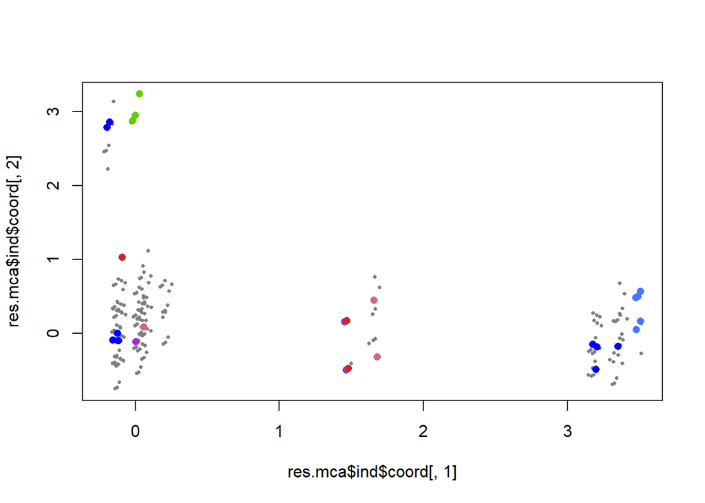

```r
# characteristic individuals
para1<-which(rownames(res.mca$ind$coord)%in%names(res.hcpcMCA$desc.ind$para[[1]]))
dist1<-which(rownames(res.mca$ind$coord)%in%names(res.hcpcMCA$desc.ind$dist[[1]]))
para2<-which(rownames(res.mca$ind$coord)%in%names(res.hcpcMCA$desc.ind$para[[2]]))
dist2<-which(rownames(res.mca$ind$coord)%in%names(res.hcpcMCA$desc.ind$dist[[2]]))
para3<-which(rownames(res.mca$ind$coord)%in%names(res.hcpcMCA$desc.ind$para[[3]]))
dist3<-which(rownames(res.mca$ind$coord)%in%names(res.hcpcMCA$desc.ind$dist[[3]]))
para4<-which(rownames(res.mca$ind$coord)%in%names(res.hcpcMCA$desc.ind$para[[4]]))
dist4<-which(rownames(res.mca$ind$coord)%in%names(res.hcpcMCA$desc.ind$dist[[4]]))
para5<-which(rownames(res.mca$ind$coord)%in%names(res.hcpcMCA$desc.ind$para[[5]]))
dist5<-which(rownames(res.mca$ind$coord)%in%names(res.hcpcMCA$desc.ind$dist[[5]]))

plot(res.mca$ind$coord[,1],res.mca$ind$coord[,2],col="grey50",cex=0.5,pch=16)
points(res.mca$ind$coord[para1,1],res.mca$ind$coord[para1,2],col="blue",cex=1,pch=16)
points(res.mca$ind$coord[dist1,1],res.mca$ind$coord[dist1,2],col="chartreuse3",cex=1,pch=16)
points(res.mca$ind$coord[para2,1],res.mca$ind$coord[para2,2],col="blue",cex=1,pch=16)
points(res.mca$ind$coord[dist2,1],res.mca$ind$coord[dist2,2],col="darkorchid3",cex=1,pch=16)
points(res.mca$ind$coord[para3,1],res.mca$ind$coord[para3,2],col="blue",cex=1,pch=16)
points(res.mca$ind$coord[dist3,1],res.mca$ind$coord[dist3,2],col="firebrick3",cex=1,pch=16)
points(res.mca$ind$coord[para4,1],res.mca$ind$coord[para4,2],col="blue",cex=1,pch=16)
points(res.mca$ind$coord[dist4,1],res.mca$ind$coord[dist4,2],col="palevioletred3",cex=1,pch=16)
points(res.mca$ind$coord[para5,1],res.mca$ind$coord[para5,2],col="blue",cex=1,pch=16)
points(res.mca$ind$coord[dist5,1],res.mca$ind$coord[dist5,2],col="royalblue1",cex=1,pch=16)
```